# Real-World Machine Learning

Chapter 5

Paul Adamson

April 2, 2017

This notebook contains R code to accompany Chapter 5 of the book [“Real-World Machine Learning”](https://www.manning.com/books/real-world-machine-learning), by Henrik Brink, Joseph W. Richards, and Mark Fetherolf. The code was contributed by [Paul Adamson](http://github.com/padamson).

*NOTE: working directory should be set to this file’s location.*

### Data for event-recommendation model

The data for the examples from this chapter are available at the [Kaggle Event Recommendation Engine Challenge](https://www.kaggle.com/c/event-recommendation-engine-challenge). The rules of the challenge prohibit redristribution of the data. To run the example code, login to [Kaggle](https://www.kaggle.com), download the data, and put the `train.csv`, `events.csv`, and `users.csv` files in a folder named `../proprietary_data/`.

### Figure 5.2 A sample of the datasets used for training the event-recommendations model

```r
dataDir <- "../proprietary_data"
# join on user and event identifiers
#from users data, get user_id, birthyear, gender, timezone
users <- read.csv(file.path(dataDir, "users.csv"),
                  colClasses = c('integer64',
                                 "NULL",
                                 "integer",
                                 "factor",
                                 "NULL",
                                 "NULL",
                                 "integer"),
                  na.strings = c("16-Mar", "23-May", "NA", "None"))

# from events data, get event_id, lat, lng
# note don't get confused about the user_id in this dataset. it is the user that created the event and is different from the user_id in the train dataset
events <- fread(file.path(dataDir, "events.csv"),
                sep=",",
                colClasses = c("integer64",
                               rep("NULL",6),
                               "numeric",
                               "numeric",
                               rep("NULL",101)))
```

```
##
Read 0.0% of 3137972 rows
Read 25.2% of 3137972 rows
Read 51.0% of 3137972 rows
Read 78.7% of 3137972 rows
Read 3137972 rows and 3 (of 110) columns from 1.092 GB file in 00:00:08
```

```r
# from train data, get user, event, invited, interested, not_interested
# rename user to user_id and event to event_id to match users and events datasets
# also need to drop observations without explicit interested or not_interested selection
# then drop not_interested since we only need one of the categorical variables
train <- read.csv(file.path(dataDir, "train.csv"),
                  colClasses = c("integer64",
                                 "integer64",
                                 "integer",
                                 "NULL",
                                 "integer",
                                 "integer"),
                  col.names = c("user_id",
                                "event_id",
                                "invited",
                                "NULL",
                                "interested",
                                "not_interested")) %>%
  subset(interested == 1 | not_interested == 1) %>%
  select(-not_interested)
```

```r
train.joined <- inner_join(train, users, by=c("user_id")) %>%
  inner_join(events, by=c("event_id")) %>%
  select(-c(user_id,event_id))
kable(head(train.joined,7))
```

| invited | interested | birthyear | gender | timezone | lat | lng |
| --- | --- | --- | --- | --- | --- | --- |
| 0 | 1 | 1990 | male | 480 | 3.567 | 98.650 |
| 0 | 1 | 1998 | female | 240 | -20.162 | 57.499 |
| 0 | 1 | 1998 | female | 240 | -20.161 | 57.499 |
| 0 | 1 | 1998 | female | 240 | -20.245 | 57.482 |
| 0 | 1 | 1982 | male | -360 | NA | NA |
| 0 | 1 | 1991 | male | 270 | NA | NA |
| 0 | 1 | 1992 | female | 420 | -6.226 | 106.507 |

## Figure 5.3 Cross-validated ROC curve and AUC metric for the simple event- recommendation model

```r
dummies <- dummyVars(" ~ .", data = train.joined, fullRank = TRUE,
                     levelsOnly = TRUE)
train.joined.numeric <- data.frame(predict(dummies, newdata = train.joined)) %>%
  select(c(-female)) %>%
  na.omit()
train.joined.numeric$interested <- factor(train.joined.numeric$interested)
train.joined.numeric$interested <-
  revalue(train.joined.numeric$interested, c("0" = "no", "1" = "yes"))
```

```r
rocCurve <- function(trueLabels, predictedProbs, nPoints = 100, posClass = 1) {
    thr <- seq(0, 1, length = nPoints)
    tpr <- numeric(nPoints)
    fpr <- numeric(nPoints)
    pos <- trueLabels == posClass
    neg <- !pos
    nPos <- sum(pos, na.rm = TRUE)
    nNeg <- sum(neg, na.rm = TRUE)
    for (i in 2:length(thr)) {
        t <- thr[i]
        meetOrExceedThreshold <- predictedProbs >= t
        tpr[i] <- sum((meetOrExceedThreshold & pos), na.rm = TRUE)/nPos
        fpr[i] <- sum((meetOrExceedThreshold & neg), na.rm = TRUE)/nNeg
    }
    duplicatedFPRs <- duplicated(fpr)
    df <- data.frame(fpr = fpr[!duplicatedFPRs], tpr = tpr[!duplicatedFPRs],
        thr = thr[!duplicatedFPRs])
    return(df)
}
```

```r
auc <- function(trueLabels, predictedProbs, nPoints = 100, posClass = 1) {
    auc <- 0
    df <- rocCurve(trueLabels = trueLabels, predictedProbs = predictedProbs,
        nPoints = nPoints, posClass = posClass)
    idx <- 3:length(df$fpr)
    auc <- as.double((df$fpr[idx - 1] - df$fpr[idx]) %*% (df$tpr[idx] + df$tpr[idx -
        1]))/2
    return(auc)
}
```

```r
plotROC <- function(trueLabels, predictedProbs, nPoints=100, posClass=1){
  auc <- auc(trueLabels, predictedProbs, nPoints, posClass)
  df <- rocCurve(trueLabels = trueLabels,
                 predictedProbs = predictedProbs,
                 nPoints = nPoints,
                 posClass = posClass)
  ggplot(df,aes(x=fpr,y=tpr)) +
    geom_step(direction="vh") +
    scale_x_continuous(limits = c(0,1)) +
    scale_y_continuous(limits = c(0,1)) +
    labs(x = "False-positive rate",
         y = "True-positive rate") +
    annotate("text", x=.5,y=.5,label=paste0("Area under the curve: ",round(auc,digits = 2)))

}
```

```r
trainIndex <- createDataPartition(train.joined.numeric$male, p = .8,
                                  list = FALSE,
                                  times = 1)

eventTrain <- train.joined.numeric[ trainIndex,]
eventTest  <- train.joined.numeric[-trainIndex,]


fitControl <- trainControl(method = "repeatedcv",
                           number = 10,
                           savePredictions = TRUE,
                           summaryFunction=twoClassSummary,
                           classProbs=TRUE)

rfFit <- train(interested ~ ., data = eventTrain,
                method = "rf",
                trControl = fitControl,
                verbose = FALSE)
event.rf.pred.prob <- predict(object=rfFit,
                              eventTest, type='prob')
```

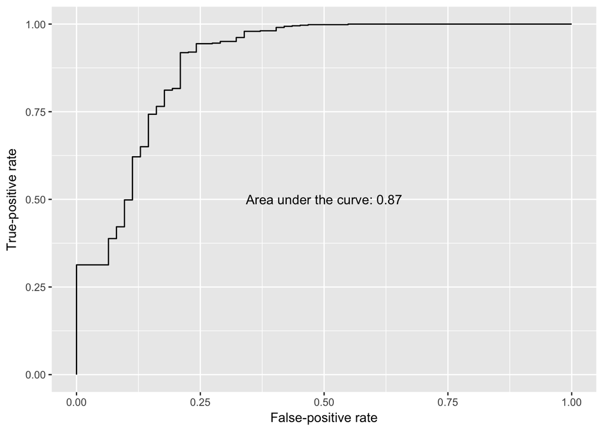

```r
plotROC(revalue(eventTest$interested, c("no" = 0, "yes" = 1)),
        event.rf.pred.prob$yes, nPoints = 1000)
```

## Figure 5.4 Additional date-time columns extracted from the timestamp column for the event-recommendation dataset

```r
# from events data, get event_id, start_time, lat, lng
# note don't get confused about the user_id in this dataset. it is the user that created the event and is different from the user_id in the train dataset
# also, doing a semi_join so we only work with the event data in the train data
# frame

events <- fread(file.path(dataDir, "events.csv"),
                sep=",",
                colClasses = c("integer64",
                               "NULL",
                               'myDateTime',
                               rep("NULL",4),
                               "numeric",
                               "numeric",
                               rep("NULL",101))) %>%
  semi_join(y = train) %>%
  mutate(datetime = strptime(start_time, format="%Y-%m-%dT%H:%M:%OS", tz="UTC"),
         datetime_year = as.numeric(substr(datetime, 1, 4)),
         datetime_month_of_year = as.numeric(substr(datetime, 6, 7)),
         datetime_day_of_month = as.numeric(substr(datetime, 9,10)),
         datetime_hour_of_day = as.numeric(substr(datetime, 12, 13)),
         datetime_minute_of_hour = as.numeric(substr(datetime, 15, 16)),
         datetime_second_of_minute = as.numeric(substr(datetime, 18, 19)),
         datetime_day_of_week = as.factor(weekdays(datetime)),
         datetime_week_of_year = week(datetime),
         datetime_quarter_of_year = quarter(datetime),
         datetime_day_of_year = as.POSIXlt(datetime)$yday
  ) %>%
  select(c(-datetime, -start_time))
```

```
##
Read 0.0% of 3137972 rows
Read 23.3% of 3137972 rows
Read 44.9% of 3137972 rows
Read 65.6% of 3137972 rows
Read 87.0% of 3137972 rows
Read 3137972 rows and 4 (of 110) columns from 1.092 GB file in 00:00:08
```

```r
kable(head(
  select(events,
         c(datetime_hour_of_day,
           datetime_day_of_week,
           datetime_day_of_month,
           datetime_day_of_year,
           datetime_month_of_year)),
  5))
```

| datetime_hour_of_day | datetime_day_of_week | datetime_day_of_month | datetime_day_of_year | datetime_month_of_year |
| --- | --- | --- | --- | --- |
| 13 | Friday | 26 | 299 | 10 |
| 7 | Saturday | 3 | 307 | 11 |
| 0 | Wednesday | 31 | 304 | 10 |
| 16 | Thursday | 1 | 305 | 11 |
| 0 | Friday | 30 | 334 | 11 |

```r
kable(head(
  select(events,
         c(datetime_minute_of_hour,
           datetime_second_of_minute,
           datetime_year,
           datetime_quarter_of_year,
           datetime_week_of_year)),
  5))
```

[output not shown]

## Figure 5.5 Cross-validated ROC curve for model including date-time features

```r
train.joined <- inner_join(train, users, by=c("user_id")) %>%
  inner_join(events, by=c("event_id")) %>%
  select(-c(user_id,event_id))

dummies <- dummyVars(" ~ .", data = train.joined, fullRank = TRUE,
                     levelsOnly = TRUE)
train.joined.numeric <- data.frame(predict(dummies, newdata = train.joined)) %>%
  select(c(-female)) %>%
  na.omit()
train.joined.numeric$interested <- factor(train.joined.numeric$interested)
train.joined.numeric$interested <-
  revalue(train.joined.numeric$interested, c("0" = "no", "1" = "yes"))

trainIndex <- createDataPartition(train.joined.numeric$male, p = .8,
                                  list = FALSE,
                                  times = 1)

eventTrain <- train.joined.numeric[ trainIndex,]
eventTest  <- train.joined.numeric[-trainIndex,]


fitControl <- trainControl(method = "repeatedcv",
                           number = 10,
                           savePredictions = TRUE,
                           summaryFunction=twoClassSummary,
                           classProbs=TRUE)

rfFit <- train(interested ~ ., data = eventTrain,
                method = "rf",
                trControl = fitControl,
                verbose = FALSE)
event.rf.pred.prob <- predict(object=rfFit,
                              eventTest, type='prob')
```

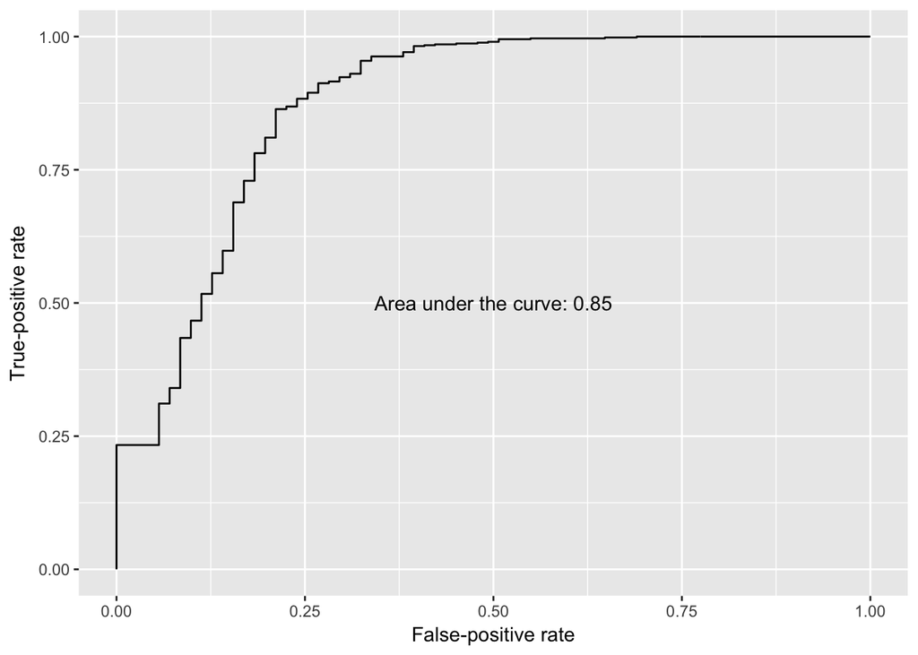

```r
plotROC(revalue(eventTest$interested, c("no" = 0, "yes" = 1)),
        event.rf.pred.prob$yes, nPoints = 1000)
```

## Figure 5.6 A slice of the bag-of-words data for the event-recommendation example. These numbers are the counts of the top-occurring words in the event descriptions. A large fraction of the cells contain 0, so we call the dataset sparse.

```r
# from events data, get event_id, start_time, lat, lng, c_1 through c_other
# note don't get confused about the user_id in this dataset. it is the user that created the event and is different from the user_id in the train dataset
# also, doing a semi_join so we only work with the event data in the train data
# frame

events <- fread(file.path(dataDir, "events.csv"),
                sep=",",
                colClasses = c("integer64",
                               "NULL",
                               'myDateTime',
                               rep("NULL",4),
                               "numeric",
                               "numeric",
                               rep("integer",101))) %>%
  semi_join(y = train) %>%
  mutate(datetime = strptime(start_time, format="%Y-%m-%dT%H:%M:%OS", tz="UTC"),
         datetime_year = as.numeric(substr(datetime, 1, 4)),
         datetime_month_of_year = as.numeric(substr(datetime, 6, 7)),
         datetime_day_of_month = as.numeric(substr(datetime, 9,10)),
         datetime_hour_of_day = as.numeric(substr(datetime, 12, 13)),
         datetime_minute_of_hour = as.numeric(substr(datetime, 15, 16)),
         datetime_second_of_minute = as.numeric(substr(datetime, 18, 19)),
         datetime_day_of_week = as.factor(weekdays(datetime)),
         datetime_week_of_year = week(datetime),
         datetime_quarter_of_year = quarter(datetime),
         datetime_day_of_year = as.POSIXlt(datetime)$yday
  ) %>%
  select(c(-datetime, -start_time))
```

```
##
Read 0.0% of 3137972 rows
Read 11.2% of 3137972 rows
Read 22.9% of 3137972 rows
Read 33.8% of 3137972 rows
Read 44.6% of 3137972 rows
Read 55.8% of 3137972 rows
Read 66.9% of 3137972 rows
Read 78.1% of 3137972 rows
Read 89.2% of 3137972 rows
Read 99.7% of 3137972 rows
Read 3137972 rows and 105 (of 110) columns from 1.092 GB file in 00:00:13
```

```r
rhandsontable(matrix(data=unlist(events[1:110,4:104]),nrow=11,ncol=10),
              readOnly = TRUE)
```

[interactive table not shown]

## Figure 5.7 Cross-validated ROC curve for full model including date-time and text features

```r
train.joined <- inner_join(train, users, by=c("user_id")) %>%
  inner_join(events, by=c("event_id")) %>%
  select(-c(user_id,event_id))

dummies <- dummyVars(" ~ .", data = train.joined, fullRank = TRUE,
                     levelsOnly = TRUE)
train.joined.numeric <- data.frame(predict(dummies, newdata = train.joined)) %>%
  select(c(-female)) %>%
  na.omit()
train.joined.numeric$interested <- factor(train.joined.numeric$interested)
train.joined.numeric$interested <-
  revalue(train.joined.numeric$interested, c("0" = "no", "1" = "yes"))

trainIndex <- createDataPartition(train.joined.numeric$male, p = .8,
                                  list = FALSE,
                                  times = 1)

eventTrain <- train.joined.numeric[ trainIndex,]
eventTest  <- train.joined.numeric[-trainIndex,]


fitControl <- trainControl(method = "repeatedcv",
                           number = 10,
                           savePredictions = TRUE,
                           summaryFunction=twoClassSummary,
                           classProbs=TRUE)

rfFit <- train(interested ~ ., data = eventTrain,
                method = "rf",
                trControl = fitControl,
                verbose = FALSE)
event.rf.pred.prob <- predict(object=rfFit,
                              eventTest, type='prob')
```

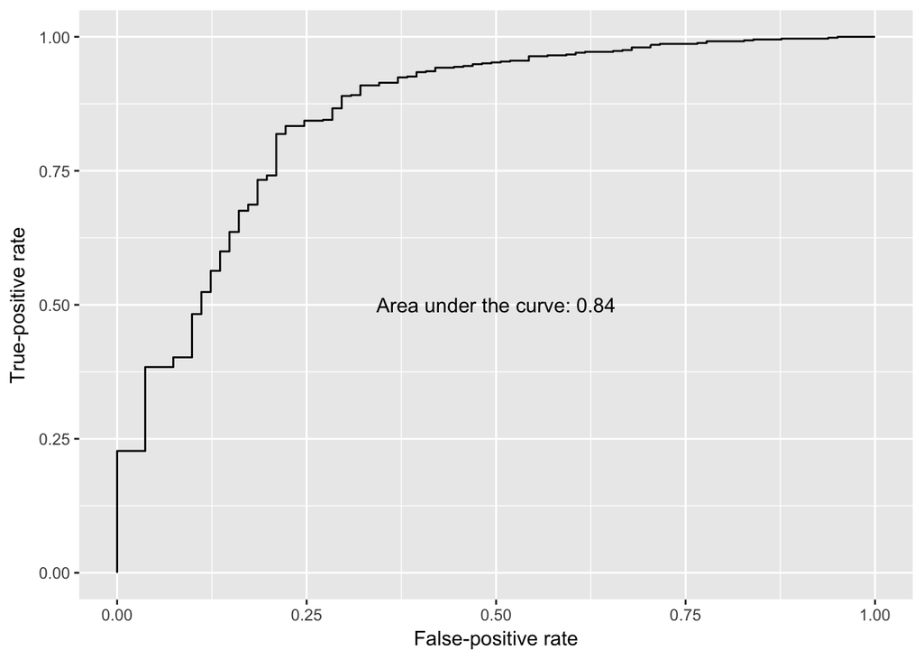

```r
plotROC(revalue(eventTest$interested, c("no" = 0, "yes" = 1)),
        event.rf.pred.prob$yes, nPoints = 1000)
```

## Inset: Some algorithms have built-in feature selection

```r
rfImp <- varImp(rfFit, scale = FALSE)
setDT(rfImp$importance, keep.rownames = TRUE)[]
```

```
##                            rn    Overall
##   1:                  invited  0.7038939
##   2:                birthyear 83.9764275
##   3:                     male  8.8013301
##   4:                 timezone 26.8073843
##   5:                      lat 35.6837413
##  ---
## 118:                  Tuesday  2.2122801
## 119:                Wednesday  2.9494567
## 120:    datetime_week_of_year 10.0579370
## 121: datetime_quarter_of_year  0.7604578
## 122:     datetime_day_of_year 21.2791525
```

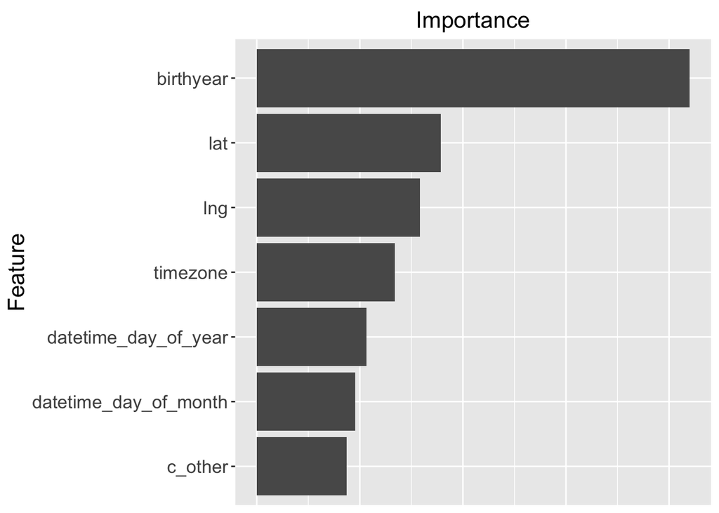

```r
rfImp$importance <-
  rfImp$importance[order(rfImp$importance$Overall,
                         decreasing = TRUE),]
rfImp$importance$rn <- reorder(rfImp$importance$rn, rfImp$importance$Overall)
ggplot(rfImp$importance[1:7], aes(x = rn, y = Overall)) +
  geom_bar(stat = "identity") +
  xlab("Feature") +
  ylab("Importance") +
  theme(axis.text.x=element_blank(),
        axis.ticks.x=element_blank()) +
  theme(text=element_text(size=16, family="Arial")) +
  scale_y_continuous(position="top") +
  #theme(axis.title.y = element_text(angle = 90, vjust = 1.08)) +
  coord_flip()
```